# Peer Assessment II

Gabriele Grasso

# Background

This analysis concerns a database of houses sold in Ames, Iowa, including various informations on the properties. The objective is to build a robust and accurate predictive model of the selling price, so that real estate investors will be able to identify undervalued or overvalued properties and neighborhoods and make data-informed choices.

# Training Data and relevant packages

In order to better assess the quality of the model we will produce, the data have been randomly divided into three separate pieces: a training data set, a testing data set, and a validation data set. For now we will load the training data set, the others will be loaded and used later.

```r
load("ames_train.Rdata")
```

The following packages are used throughout the data analysis.

```r
library(statsr)
library(dplyr)
library(BAS)
library(ggplot2)
library(MASS)
```

## Part 1 - Exploratory Data Analysis (EDA)

Exploratory Data Analysis allows for a preliminary understanding of the relationship between the different variables and a selection of the most important features that will be included in the multiple linear regression.

The database contains sales of houses built between 1872 and 2010. It is interesting to see how these properties are distributed by age at the time of the survey, as in the following plot.

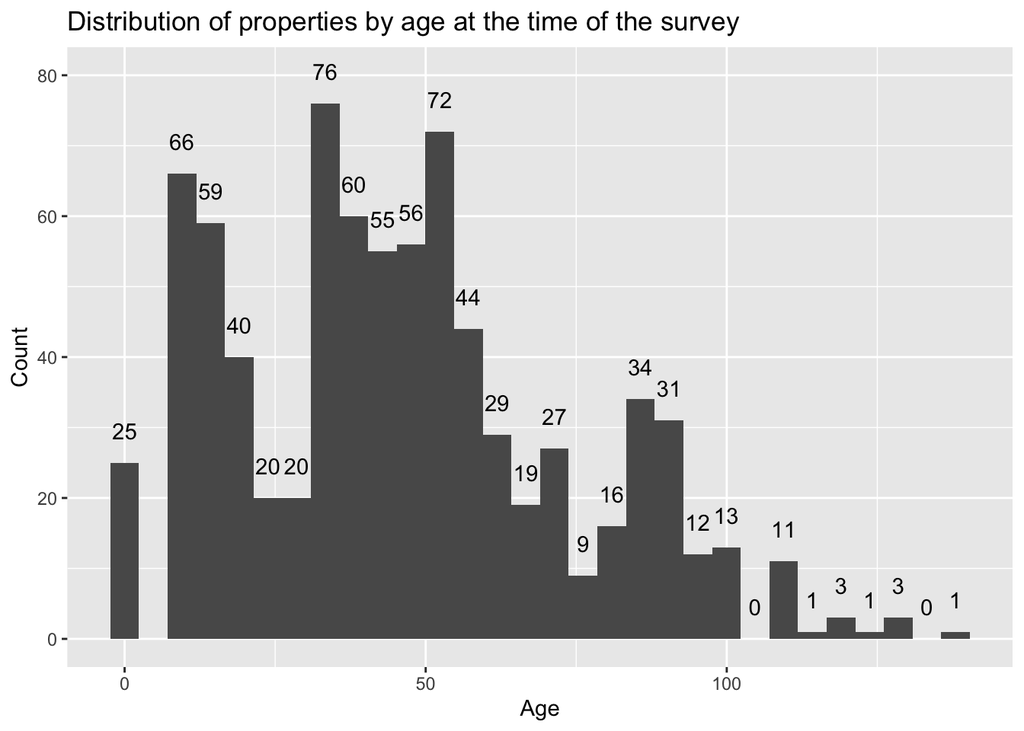

```r
# type your code for Question 1 here, and Knit
ggplot(ames_train,aes(x=2010 - Year.Built)) +
    stat_bin(bins = 30) + ylim(c(0, 135)) +
    stat_bin(bins=30, geom="text", aes(label=..count..), vjust=-1.5) + labs(title = "Distribution of properties by age at the time of the survey", x = 'Age', y = 'Count') +
  coord_cartesian(ylim = c(0, 80))
```

It appears that the age distribution is strongly right-skewed, with a large number of new houses, and multi-modal. In fact, it appears there have been two periods of intensive house-building: one at the beginning of the 21st century and another earlier between the Fifties and the Seventies.

For the purpose of building a linear model of price, we assume that all observations in the database are generated from the same process. Therefore, we need check if the distribution of price depends on the various sale conditions listed under the **Sale.Condition** variable.

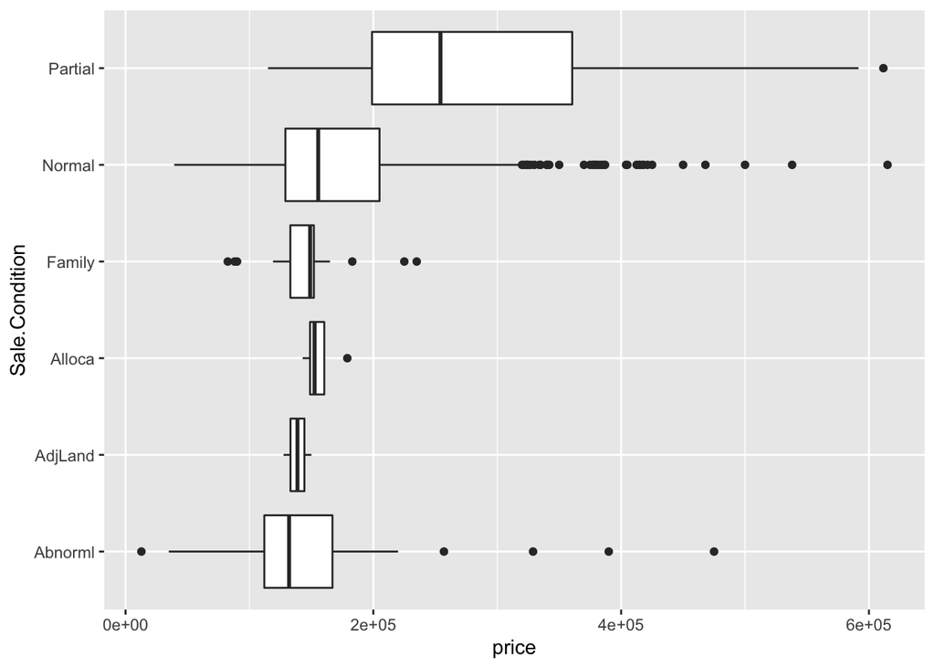

```r
ggplot(data = ames_train, mapping = aes(x = Sale.Condition, y = price)) + geom_boxplot() + coord_flip()
```

The range of prices is clearly affected by the sale condition. Sale conditions other than **Normal** generate prices that do not reflect the actual market value of a property, therefore the corresponding data may be discarded. The following code calculates the percentage of data that would be kept after the exclusion of houses sold in conditions other than normal.

```r
ames_train_normal <- subset(ames_train, Sale.Condition == 'Normal')
dim(ames_train_normal)[1]/dim(ames_train)[1]*100
```

```
## [1] 83.4
```

This is still a reasonable amount of data, therefore we will proceed with the selection of all properties sold in normal conditions.

```r
ames_train <- ames_train %>%
  filter(Sale.Condition == "Normal")
```

The next scatter plot shows the linear relationship of **log(price)** to **log(area)**, highlighted by the linear regression line in blue, surrounded by the confidence interval of the mean predicted **log(price)** for any given **log(area)**. The points are colored by the Overall Quality score of the property, showing that the price increases proportionally to this variable as well.

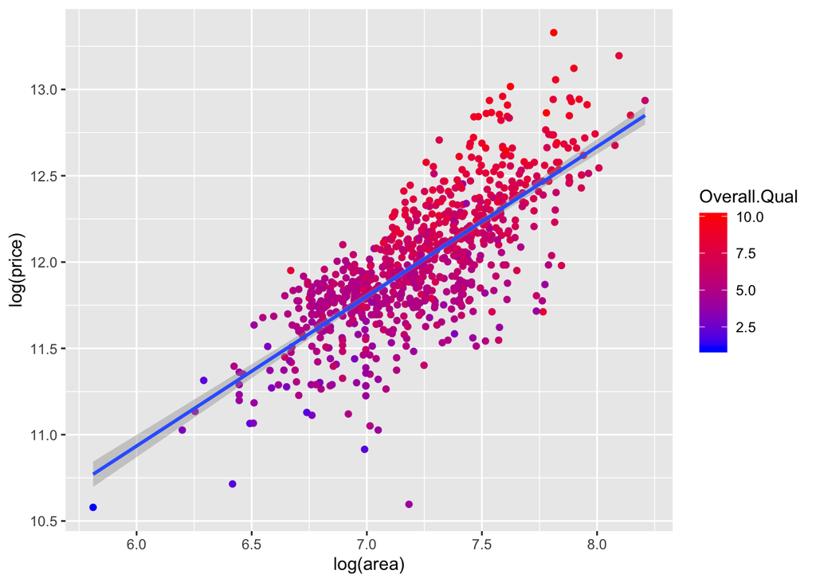

```r
ggplot(data = ames_train, mapping = aes(x = log(area), y = log(price), color = Overall.Qual)) + geom_point() + scale_color_gradient(low="blue", high="red")  + geom_smooth(method='lm')
```

## Part 2 - Development and assessment of an initial model, following a semi-guided process of analysis

### Section 2.1 An Initial Model

```r
ames_reduced <- dplyr::select(ames_train, 'price', 'area', 'Lot.Area',
                              'Bedroom.AbvGr', 'Overall.Qual', 'Exter.Qual', 'Year.Remod.Add', 'Central.Air', 'Land.Slope')

n <- nrow(na.omit(ames_reduced))
m.init <- lm(log(price) ~ log(area) + log(Lot.Area) +
               Bedroom.AbvGr + Overall.Qual + Exter.Qual + Year.Remod.Add + Central.Air + Land.Slope, data = na.omit(ames_reduced))

summary(m.init)
```

```
##
## Call:
## lm(formula = log(price) ~ log(area) + log(Lot.Area) + Bedroom.AbvGr +
##     Overall.Qual + Exter.Qual + Year.Remod.Add + Central.Air +
##     Land.Slope, data = na.omit(ames_reduced))
##
## Residuals:
##      Min       1Q   Median       3Q      Max
## -0.79846 -0.07782  0.00729  0.09589  0.48225
##
## Coefficients:
##                  Estimate Std. Error t value Pr(>|t|)
## (Intercept)     2.2581883  0.6306717   3.581 0.000363 ***
## log(area)       0.4135878  0.0259207  15.956  < 2e-16 ***
## log(Lot.Area)   0.1439500  0.0105897  13.593  < 2e-16 ***
## Bedroom.AbvGr  -0.0310307  0.0084052  -3.692 0.000237 ***
## Overall.Qual    0.1118077  0.0062629  17.852  < 2e-16 ***
## Exter.QualFa   -0.2639884  0.0668807  -3.947 8.59e-05 ***
## Exter.QualGd   -0.1630270  0.0352778  -4.621 4.43e-06 ***
## Exter.QualTA   -0.2301558  0.0390798  -5.889 5.65e-09 ***
## Year.Remod.Add  0.0024306  0.0003133   7.757 2.57e-14 ***
## Central.AirY    0.2541023  0.0237278  10.709  < 2e-16 ***
## Land.SlopeMod   0.0844245  0.0267407   3.157 0.001651 **
## Land.SlopeSev   0.0456945  0.0853230   0.536 0.592416
## ---
## Signif. codes:  0 '***' 0.001 '**' 0.01 '*' 0.05 '.' 0.1 ' ' 1
##
## Residual standard error: 0.1411 on 822 degrees of freedom
## Multiple R-squared:  0.8653, Adjusted R-squared:  0.8634
## F-statistic: 479.8 on 11 and 822 DF,  p-value: < 2.2e-16
```

As can be seen from the previous summary of the multivariate linear model, all coefficients have a very low probability of being null, except of the variable representing the land slope. Also, the adjusted $R^2$ score of the model, which represents the fraction of the variation of $log(price)$ accounted for by the variation of the explanatory variables, is equal to 0.8634, which is a very satisfactory result.

### Section 2.2 Model Selection

In order to select a parsimonious model from the initial linear regression model developed in the previous section, we will test two different selection procedures: the Akaike Information Criterion (AIC) and the Bayesian Information Criterion (BIC). Both are applied in a stepwise fashion.

First, the results of the AIC selection are shown below.

```r
n <- nrow(na.omit(ames_reduced))

# k=2 gives genuine AIC criterion
m.init.AIC <- stepAIC(m.init, k = 2)
```

```
## Start:  AIC=-3254.27
## log(price) ~ log(area) + log(Lot.Area) + Bedroom.AbvGr + Overall.Qual +
##     Exter.Qual + Year.Remod.Add + Central.Air + Land.Slope
##
##                  Df Sum of Sq    RSS     AIC
## <none>                        16.370 -3254.3
## - Land.Slope      2    0.2014 16.572 -3248.1
## - Bedroom.AbvGr   1    0.2714 16.642 -3242.6
## - Exter.Qual      3    0.7843 17.154 -3221.2
## - Year.Remod.Add  1    1.1984 17.569 -3197.3
## - Central.Air     1    2.2839 18.654 -3147.3
## - log(Lot.Area)   1    3.6799 20.050 -3087.2
## - log(area)       1    5.0702 21.440 -3031.2
## - Overall.Qual    1    6.3470 22.717 -2983.0
```

```r
summary(m.init.AIC)
```

```
##
## Call:
## lm(formula = log(price) ~ log(area) + log(Lot.Area) + Bedroom.AbvGr +
##     Overall.Qual + Exter.Qual + Year.Remod.Add + Central.Air +
##     Land.Slope, data = na.omit(ames_reduced))
##
## Residuals:
##      Min       1Q   Median       3Q      Max
## -0.79846 -0.07782  0.00729  0.09589  0.48225
##
## Coefficients:
##                  Estimate Std. Error t value Pr(>|t|)
## (Intercept)     2.2581883  0.6306717   3.581 0.000363 ***
## log(area)       0.4135878  0.0259207  15.956  < 2e-16 ***
## log(Lot.Area)   0.1439500  0.0105897  13.593  < 2e-16 ***
## Bedroom.AbvGr  -0.0310307  0.0084052  -3.692 0.000237 ***
## Overall.Qual    0.1118077  0.0062629  17.852  < 2e-16 ***
## Exter.QualFa   -0.2639884  0.0668807  -3.947 8.59e-05 ***
## Exter.QualGd   -0.1630270  0.0352778  -4.621 4.43e-06 ***
## Exter.QualTA   -0.2301558  0.0390798  -5.889 5.65e-09 ***
## Year.Remod.Add  0.0024306  0.0003133   7.757 2.57e-14 ***
## Central.AirY    0.2541023  0.0237278  10.709  < 2e-16 ***
## Land.SlopeMod   0.0844245  0.0267407   3.157 0.001651 **
## Land.SlopeSev   0.0456945  0.0853230   0.536 0.592416
## ---
## Signif. codes:  0 '***' 0.001 '**' 0.01 '*' 0.05 '.' 0.1 ' ' 1
##
## Residual standard error: 0.1411 on 822 degrees of freedom
## Multiple R-squared:  0.8653, Adjusted R-squared:  0.8634
## F-statistic: 479.8 on 11 and 822 DF,  p-value: < 2.2e-16
```

It can be seen that all the predictors included in the original model are kept after the stepwise AIC process.

Secondly, the BIC selection is applied by the following code.

```r
# k=log(n) gives BIC criterion
m.init.BIC <- stepAIC(m.init, k = log(n))
```

```
## Start:  AIC=-3197.55
## log(price) ~ log(area) + log(Lot.Area) + Bedroom.AbvGr + Overall.Qual +
##     Exter.Qual + Year.Remod.Add + Central.Air + Land.Slope
##
##                  Df Sum of Sq    RSS     AIC
## - Land.Slope      2    0.2014 16.572 -3200.8
## <none>                        16.370 -3197.6
## - Bedroom.AbvGr   1    0.2714 16.642 -3190.6
## - Exter.Qual      3    0.7843 17.154 -3178.7
## - Year.Remod.Add  1    1.1984 17.569 -3145.4
## - Central.Air     1    2.2839 18.654 -3095.4
## - log(Lot.Area)   1    3.6799 20.050 -3035.2
## - log(area)       1    5.0702 21.440 -2979.3
## - Overall.Qual    1    6.3470 22.717 -2931.0
##
## Step:  AIC=-3200.81
## log(price) ~ log(area) + log(Lot.Area) + Bedroom.AbvGr + Overall.Qual +
##     Exter.Qual + Year.Remod.Add + Central.Air
##
##                  Df Sum of Sq    RSS     AIC
## <none>                        16.572 -3200.8
## - Bedroom.AbvGr   1    0.3363 16.908 -3190.8
## - Exter.Qual      3    0.8465 17.418 -3179.4
## - Year.Remod.Add  1    1.2276 17.799 -3147.9
## - Central.Air     1    2.3322 18.904 -3097.7
## - log(Lot.Area)   1    4.3540 20.926 -3013.0
## - log(area)       1    5.3092 21.881 -2975.7
## - Overall.Qual    1    6.1989 22.770 -2942.5
```

```r
summary(m.init.BIC)
```

```
##
## Call:
## lm(formula = log(price) ~ log(area) + log(Lot.Area) + Bedroom.AbvGr +
##     Overall.Qual + Exter.Qual + Year.Remod.Add + Central.Air,
##     data = na.omit(ames_reduced))
##
## Residuals:
##      Min       1Q   Median       3Q      Max
## -0.80102 -0.07905  0.00603  0.09543  0.47396
##
## Coefficients:
##                  Estimate Std. Error t value Pr(>|t|)
## (Intercept)     2.1327334  0.6322964   3.373 0.000778 ***
## log(area)       0.4212460  0.0259262  16.248  < 2e-16 ***
## log(Lot.Area)   0.1491649  0.0101377  14.714  < 2e-16 ***
## Bedroom.AbvGr  -0.0342311  0.0083710  -4.089 4.75e-05 ***
## Overall.Qual    0.1099115  0.0062604  17.557  < 2e-16 ***
## Exter.QualFa   -0.2594196  0.0671696  -3.862 0.000121 ***
## Exter.QualGd   -0.1764722  0.0351007  -5.028 6.10e-07 ***
## Exter.QualTA   -0.2425339  0.0389778  -6.222 7.79e-10 ***
## Year.Remod.Add  0.0024590  0.0003147   7.813 1.70e-14 ***
## Central.AirY    0.2566260  0.0238308  10.769  < 2e-16 ***
## ---
## Signif. codes:  0 '***' 0.001 '**' 0.01 '*' 0.05 '.' 0.1 ' ' 1
##
## Residual standard error: 0.1418 on 824 degrees of freedom
## Multiple R-squared:  0.8636, Adjusted R-squared:  0.8621
## F-statistic: 579.6 on 9 and 824 DF,  p-value: < 2.2e-16
```

The BIC method is known to produce more parsimonious models, especially for large databases. In this case, the variable *Land.Slope* has been dropped. The model resulting from the BIC is preferred because it uses less explanatory variables and is still capable of accounting for $86\%$ of the variation of *log(price)*.

### Section 2.3 Initial Model Residuals

The performance of this initial BIC model is assessed by plotting the residuals versus the predicted values. For better understanding, the data are converted in Dollar units.

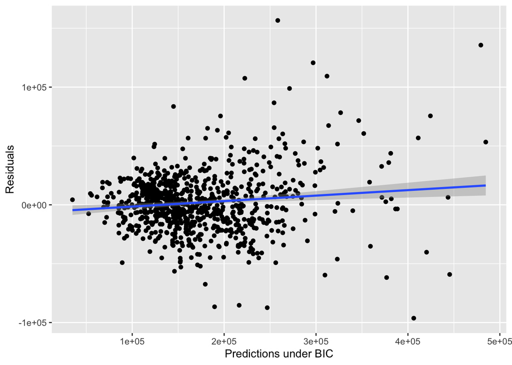

```r
# Extract Predictions
predict.init <- exp(predict(m.init.BIC, ames_reduced))

# Extract Residuals
resid.init <- ames_reduced$price - predict.init

ggplot(mapping = aes(x = predict.init, y = resid.init)) + geom_point() + geom_smooth(method='lm') + labs(x = 'Predictions under BIC', y = 'Residuals')
```

It can be seen that the average of the residuals tends to diverge from the expected value of zero for increasing predicted price. Next, we normalize the residuals by their average and standard deviation and generate a quantile-quantile plot.

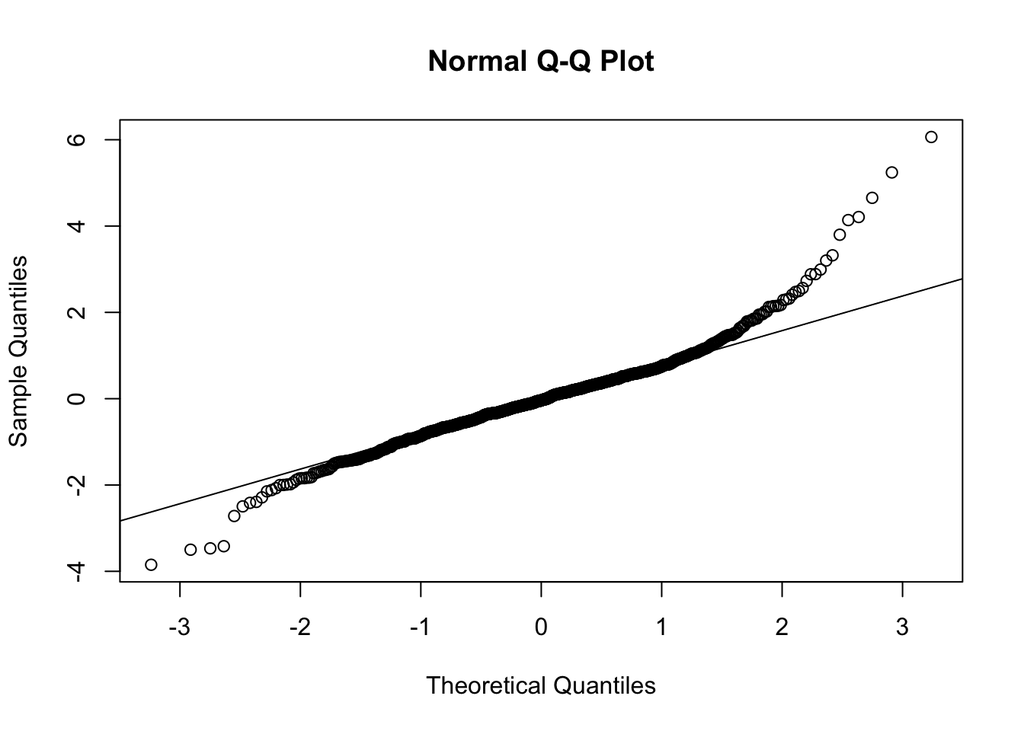

```r
# Normalize residuals
mu_resid <- mean(resid.init)
sd_resid <- sd(resid.init)
std_resid.init <- (resid.init - mu_resid)/sd_resid

# Normal Q-Q plot
qqnorm(std_resid.init, lty = 2)
qqline(std_resid.init)
```

It can be seen that the residuals that are more than two standard deviations away from the average diverge from the expected normal distribution. The previous two plots suggest that the linear regression approach that has been taken in this initial attempt needs some improvement in order to fulfill the assumptions of a linear model.

### Section 2.4 Initial Model RMSE

A metric of the model performance is the root mean squared error (RMSE), which corresponds the square root of the mean of the squared residuals. The unit of the following result is dollars, consistently with the previous residual plots.

```r
# Calculate RMSE
rmse.init <- sqrt(mean(resid.init^2))
rmse.init
```

```
## [1] 25576.77
```

### Section 2.5 Overfitting

The initial model has been trained, and therefore optimized, on a given database. In order to evaluate the performance of this model on different data, we load a *test* database.

```r
load("ames_test.Rdata")
ames_test <- ames_test %>%
  filter(Sale.Condition == "Normal")
```

```r
# Extract Predictions
predict.init.test <- exp(predict(m.init.BIC, ames_test))

# Extract Residuals
resid.init.test <- ames_test$price - predict.init.test

# Calculate RMSE
rmse.init.test <- sqrt(mean(resid.init^2))
rmse.init.test
```

```
## [1] 25576.77
```

```r
# Predict prices
predict.int <- exp(predict(m.init.BIC, ames_test, interval = "prediction"))

# Calculate proportion of observations that fall within prediction intervals
coverage.prob.int <- mean(ames_test$price > predict.int[,"lwr"] &
                            ames_test$price < predict.int[,"upr"])
coverage.prob.int
```

```
## [1] 0.9534884
```

So the condition of coverage probability is verified.

## Part 3 - Development of a Final Model

### Section 3.1 Final Model

The following code applies the BAS algorithm and outputs its results with the `summary` function.

```r
model.bas <- bas.lm(log(price) ~ Overall.Qual + log(Garage.Area + 1) +
                  log(Total.Bsmt.SF + 1) + Garage.Cars + log(area) +
                  Full.Bath + Half.Bath +
                  Bedroom.AbvGr + Year.Built + Year.Remod.Add + log(X1st.Flr.SF) +
                  log(X2nd.Flr.SF + 1) + log(Pool.Area + 1) +
                  log(Lot.Area) +  Central.Air + Overall.Cond,
                 data = ames_train, prior = "AIC", modelprior=uniform())

summary(model.bas)
```

```
##                        P(B != 0 | Y)    model 1       model 2
## Intercept                  1.0000000     1.0000     1.0000000
## Overall.Qual               1.0000000     1.0000     1.0000000
## log(Garage.Area + 1)       0.4546634     0.0000     0.0000000
## log(Total.Bsmt.SF + 1)     1.0000000     1.0000     1.0000000
## Garage.Cars                0.9999915     1.0000     1.0000000
## log(area)                  1.0000000     1.0000     1.0000000
## Full.Bath                  0.3748592     0.0000     0.0000000
## Half.Bath                  0.3107058     0.0000     0.0000000
## Bedroom.AbvGr              0.9999997     1.0000     1.0000000
## Year.Built                 1.0000000     1.0000     1.0000000
## Year.Remod.Add             0.9286138     1.0000     1.0000000
## log(X1st.Flr.SF)           0.8459015     1.0000     1.0000000
## log(X2nd.Flr.SF + 1)       0.4612034     0.0000     0.0000000
## log(Pool.Area + 1)         0.5196158     1.0000     0.0000000
## log(Lot.Area)              1.0000000     1.0000     1.0000000
## Central.AirY               0.9946033     1.0000     1.0000000
## Overall.Cond               1.0000000     1.0000     1.0000000
## BF                                NA     1.0000     0.9811866
## PostProbs                         NA     0.0583     0.0572000
## R2                                NA     0.9067     0.9065000
## dim                               NA    13.0000    12.0000000
## logmarg                           NA -1025.2350 -1025.2539581
##                              model 3       model 4       model 5
## Intercept                  1.0000000     1.0000000     1.0000000
## Overall.Qual               1.0000000     1.0000000     1.0000000
## log(Garage.Area + 1)       1.0000000     1.0000000     0.0000000
## log(Total.Bsmt.SF + 1)     1.0000000     1.0000000     1.0000000
## Garage.Cars                1.0000000     1.0000000     1.0000000
## log(area)                  1.0000000     1.0000000     1.0000000
## Full.Bath                  0.0000000     0.0000000     0.0000000
## Half.Bath                  0.0000000     0.0000000     0.0000000
## Bedroom.AbvGr              1.0000000     1.0000000     1.0000000
## Year.Built                 1.0000000     1.0000000     1.0000000
## Year.Remod.Add             1.0000000     1.0000000     1.0000000
## log(X1st.Flr.SF)           1.0000000     1.0000000     1.0000000
## log(X2nd.Flr.SF + 1)       0.0000000     0.0000000     1.0000000
## log(Pool.Area + 1)         1.0000000     0.0000000     1.0000000
## log(Lot.Area)              1.0000000     1.0000000     1.0000000
## Central.AirY               1.0000000     1.0000000     1.0000000
## Overall.Cond               1.0000000     1.0000000     1.0000000
## BF                         0.7866852     0.7736111     0.6025437
## PostProbs                  0.0459000     0.0451000     0.0351000
## R2                         0.9069000     0.9067000     0.9069000
## dim                       14.0000000    13.0000000    14.0000000
## logmarg                -1025.4748926 -1025.4916514 -1025.7415606
```

The first column of the previous table corresponds to the posterior inclusion probability of each model coefficient given the training data set, $P(B \neq 0\, |\, Y)$. The following columns correspond to the first five linear regression models with highest posterior probability (`PostProbs`) in descending order. The zeros and ones indicate if a variable is present in the model or not. Other values tabulated for each model are the Bayes factor (`BF`) of the model with respect to the Highest Probability Model (HPM), the R-squared (`R2`) in the ordinary least squares sense, the number of variables (`dim`) and the log of marginal likelihood (`logmarg`). It can be noticed that the first five models all have $R^2$ around $90\%$, which is an improvement with respect to the initial linear regression model obtained with the classical frequentist approach.

The posterior inclusion probabilities (PIP) of the explanatory variables are plotted below. The values above $50\%$ are highlighted in blue.

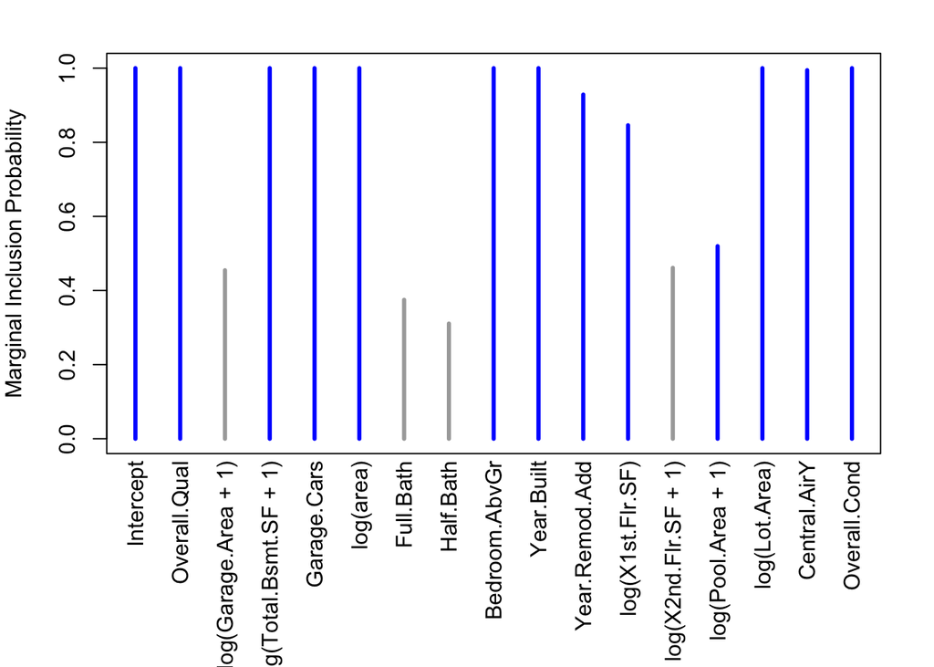

```r
par(mar=c(8,4,2,2))
plot(model.bas, which = 4, ask = F, caption = "", sub.caption = "", col.in = "blue", col.ex = "darkgrey", lwd = 3)
```

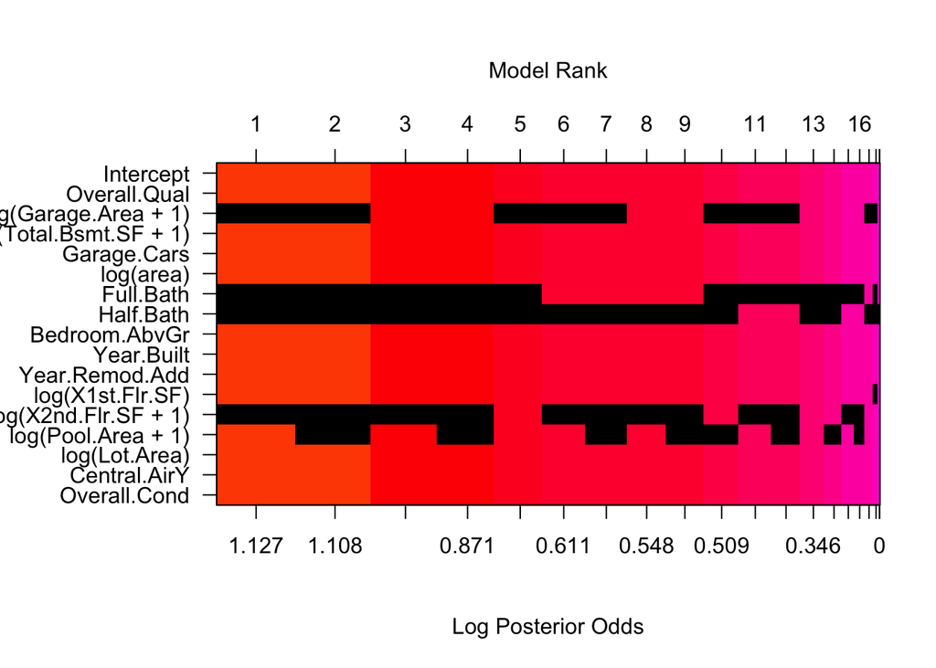

```r
image(model.bas, rotate = FALSE)
```

### Section 3.2 Transformation

Following the EDA, we decided to work on the prediction of the natural logarithm of price, taking the natural logarithm of all variables representing areas as well. In case one area-related variable can take the zero value, the variable is transformed adding “1” because the logarithm of zero is minus infinity.

### Section 3.3 Variable Interaction

No variable interactions have been included in the final model. It will be shown *a posteriori* that this choice provides acceptable results.

### Section 3.4 Variable Selection

The variables included in the final model were selected after we familiarized ourselves with the training database by means of the EDA and by building an initial simplified linear model. The choice was also aided by a certain degree of knowledge of the market and of the factors that influence the demand of properties.

### Section 3.5 Model Testing

```r
pred.test.HPM <- predict(model.bas, newdata = ames_test, estimator="HPM")
pred.HPM.rmse <- sqrt(mean((exp(pred.test.HPM$fit) - ames_test$price)^2))
pred.HPM.rmse
```

```
## [1] 24556.14
```

```r
pred.test.BPM <- predict(model.bas, newdata = ames_test, estimator="BPM")
pred.BPM.rmse <- sqrt(mean((exp(pred.test.BPM$fit) - ames_test$price)^2))
pred.BPM.rmse
```

```
## [1] 24573.38
```

```r
pred.test.BMA <- predict(model.bas, newdata = ames_test, estimator="BMA", prediction=TRUE, se.fit=TRUE)
pred.BMA.rmse <- sqrt(mean((exp(pred.test.BMA$fit) - ames_test$price)^2))
pred.BMA.rmse
```

```
## [1] 24455.5
```

It can be seen that the BMA model has the lowest RMSE calculated on out-of-sample data and is therefore retained for the final evaluation.

## Part 4 - Final Model Assessment

### Section 4.1 Final Model Residual

In this section, the residuals of the predictions obtaines by applying the BMA model to the `ames_test` data set are presented. We will compare the residuals obtained on the complete range of predicted values with a subset of the residuals corresponding to a reduced range of predicted values.

#### Full range of predicted values

The first residuals vs predicted values plot shows that the quality of the prediction worsens for predicted values above 300k$, with the average residual tending to be below zero.

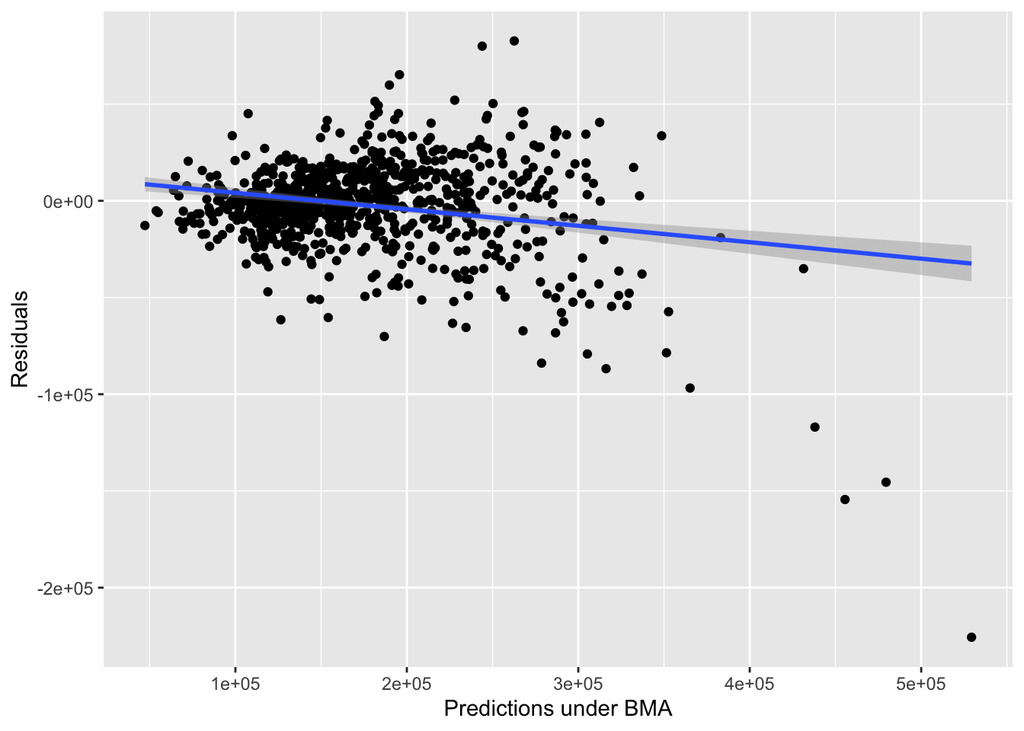

```r
pred.test.BMA.resid <- exp(pred.test.BMA$fit) - ames_test$price
ggplot(mapping = aes(x = exp(pred.test.BMA$fit) , y = pred.test.BMA.resid )) + geom_point() + geom_smooth(method='lm') + labs(x = 'Predictions under BMA', y = 'Residuals')
```

As can be seen in the following plot, the residuals with strongly negative values tend to diverge from a normal distribution around the zero mean.

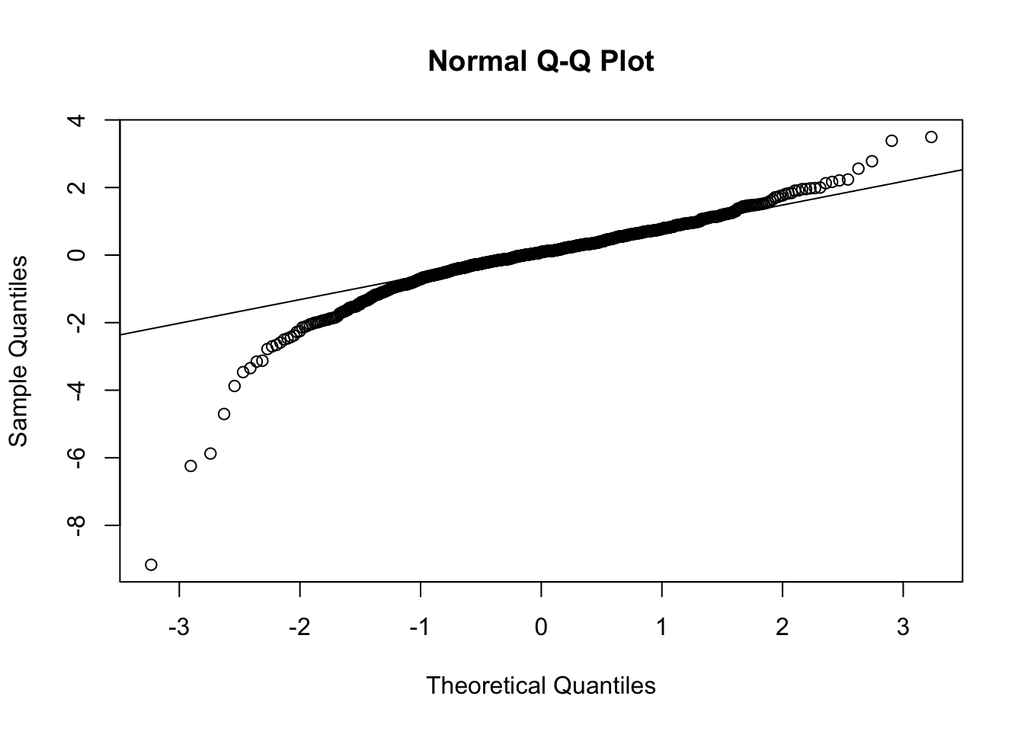

```r
# Normalize residuals
mu_resid <- mean(pred.test.BMA.resid)
sd_resid <- sd(pred.test.BMA.resid)
std_resid.test <- (pred.test.BMA.resid - mu_resid)/sd_resid

# Normal Q-Q plot
qqnorm(std_resid.test, lty = 2)
qqline(std_resid.test)
```

#### Reduced range of predicted values

In order to provide a proper range of application for the linear regression model, we re-plot the residuals only for predicted sale prices below 300k$.

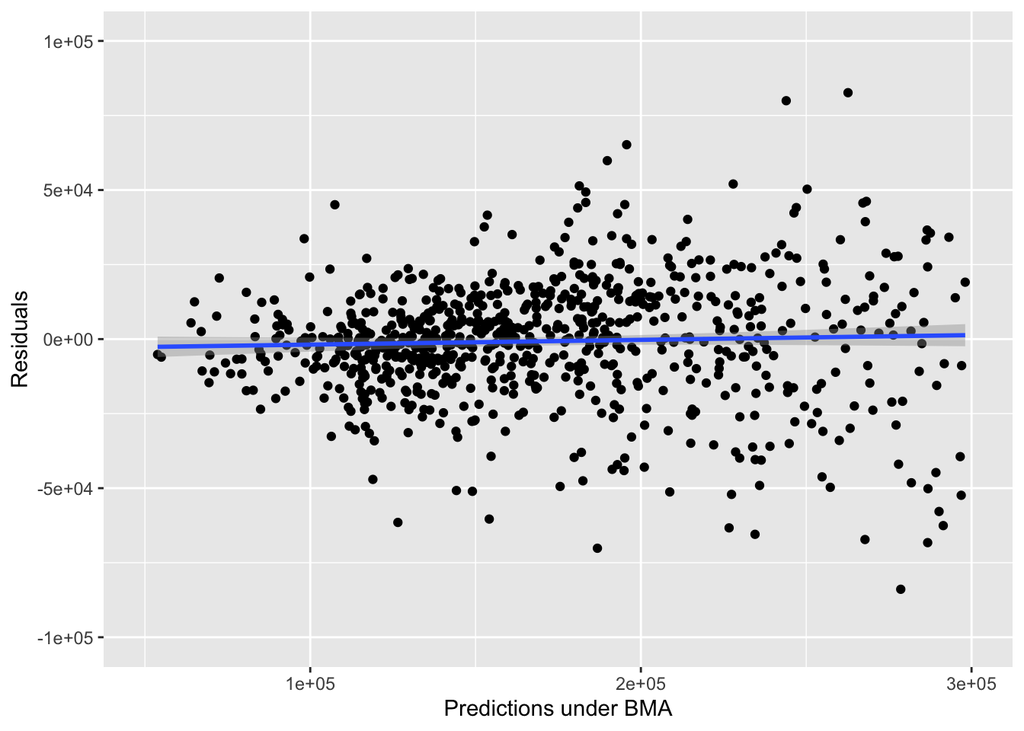

```r
ggplot(mapping = aes(x = exp(pred.test.BMA$fit) , y = pred.test.BMA.resid )) + geom_point() + xlim(50000, 300000) + ylim(-100000, 100000) + geom_smooth(method='lm') + labs(x = 'Predictions under BMA', y = 'Residuals')
```

As can be seen, in this range the residuals are more evenly spread around the zero mean value. We can also plot their quantile-quantile distribution, compared with the theoretical normal distribution.

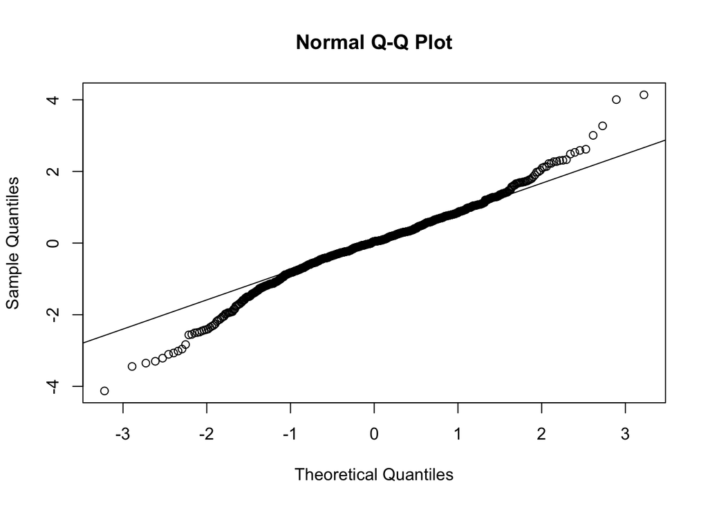

```r
res <- dplyr::filter(as.data.frame(pred.test.BMA.resid), exp(pred.test.BMA$fit) < 300000 )

# Normalize residuals
mu_resid <- mean(res$pred.test.BMA.resid)
sd_resid <- sd(res$pred.test.BMA.resid)
std_resid.test <- (res$pred.test.BMA.resid - mu_resid)/sd_resid

# Normal Q-Q plot
qqnorm(std_resid.test, lty = 2)
qqline(std_resid.test)
```

In this range of values, the residuals are much closer to a normal distribution.

### Section 4.2 Final Model RMSE

The RMSE of the final model has been calculated in Section 3.5 and has a value of 24455.5$. This is better than the one obtained with the initial simplified linear regression model.

### Section 4.3 Final Model Evaluation

As a final test, we calculate the coverage probability of the BMA model using the `ames_test` database.

```r
# Get dataset of predictions and confidence intervals
out = as.data.frame(cbind(exp(confint(pred.test.BMA)),
                          price = ames_test$price))

# Fix names in dataset
colnames(out)[1:2] <- c("lwr", "upr")  #fix names

# Get Coverage
pred.test.BMA.coverage <- out %>% summarize(cover = sum(price >= lwr & price <= upr)/n())
pred.test.BMA.coverage
```

```
##       cover
## 1 0.9461444
```

This value is fairly close to $95\%$, as expected. The main drawback of the final model is that it tends to underpredict the price of the most expensive houses, as shown by the analysis of the residuals.

### Section 4.4 Final Model Validation

For the validation of the final linear regression model we use a third independent data set, from which once again we select only the houses sold in Normal conditions.

```r
load("ames_validation.Rdata")
ames_validation <- ames_validation %>%
  filter(Sale.Condition == "Normal")
```

First, we predict the `log(price)` from the `ames_validation` data set using the BMA model.

```r
# Predict log(price) on validation database
pred.valid.BMA <- predict(model.bas, newdata = ames_validation, estimator="BMA", prediction=TRUE, se.fit=TRUE)
```

Then, we proceed to checking the RMSE, which is expressed in Dollars.

```r
# Calculate RMSE
pred.valid.BMA.rmse <- sqrt(mean((exp(pred.valid.BMA$fit) - ames_validation$price)^2))
pred.valid.BMA.rmse
```

```
## [1] 21738.66
```

In this case, the RMSE is noticeably lower than with the `ames_test` database, suggesting that the performance of this model is subject to a certain degree of variability. Finally, we calculate the coverage probability on the `ames_validation` database.

```r
# Calculate coverage
out = as.data.frame(cbind(exp(confint(pred.valid.BMA)),
                          price = ames_validation$price))

colnames(out)[1:2] <- c("lwr", "upr")  #fix names

pred.valid.BMA.coverage <- out %>% summarize(cover = sum(price >= lwr & price <= upr)/n())
pred.valid.BMA.coverage
```

```
##       cover
## 1 0.9554391
```

The percentage of the 95% predicted credible intervals that contain the true price of the house in the validation data set is again close to $95\%$.

Finally, we will try to answer the original question of this study: where are most of the overvalued and undervalued houses located? Overvalued properties will have a negative residual, whereas undervalued properties will have positive residuals. Let us calculate the average residuals grouped by neighborhood.

```r
pred.valid.BMA.resid <- exp(pred.valid.BMA$fit) - ames_validation$price
out <- cbind.data.frame(res = pred.valid.BMA.resid,
                          neigh = ames_validation$Neighborhood)
grouped_mean_res <- out %>% group_by(neigh) %>% summarize(m = mean(res))
```

The following neighborhood contains, on average, most of the overvalued properties:

```r
grouped_mean_res[which.min(grouped_mean_res$m),1]
```

```
## # A tibble: 1 x 1
##   neigh
##   <fct>
## 1 NoRidge
```

On the contrary, most of the undervalued properties can be found, on average, in the following neighborhood:

```r
grouped_mean_res[which.max(grouped_mean_res$m),1]
```

```
## # A tibble: 1 x 1
##   neigh
##   <fct>
## 1 SawyerW
```

This is then the neighborhood in which good investments can be made.

## Part 5 - Conclusion

It has been shown that the Bayesian Adaptive Sampling method can efficiently generate a linear model of the price of houses in Ames, Iowa given the current dataset. In order to obtain this result, it has been necessary to eliminate most of the potential outliers, i.e. the houses sold in conditions other than normal, and to transform the price and area variables by taking their natural logarithm. At the end of this study, the most important question is: what determines the price of the most expensive houses? It may be that there is some key variable that plays a role only above a certain threshold of price, which has not been included in the present model. This will certainly require further investigation.